# AR_BIMBOA.MX_ACarrillo,-RGarcía,-EMarquez_5

Hecho por: Alan Carrillo, Rodolfo García y Esteban Márquez

Fecha: 1 de mayo del 2022

# 1 Parte 5: Valor en Riesgo.

#### 1.0.0.1 Instrucciones.

- Seleccionar un activo además del propio y con los dos construir un portafolio que contenga **100 acciones de cada activo**. Determinar el Valor en Riesgo paramétrico y no paramétrico del portafolio ficticio a **1,5,10 y 20 días**. En el caso de la metodología no paramétrica el estudiante deberá utilizar simulación histórica (con datos desde 2016 y el valor de So del día que se aplique la metodología en clase). En el caso de estimación paramétrica deberá usar el valor de la **volatilidad promedio diaria** de los últimos seis meses y el valor de So, será el del que se aplique la metodología en clase.

• En el caso de la estimación **No paramétrica** deberá presentar la *gráfica correspondiente donde se aprecia el VaR a un día a los tres niveles de confianza estimados*.

• Hacer el **Backtesting** para el VaR a un día de ambas metodologías.

• Encontrar la **composición óptima** del portafolio que minimice el Valor en Riesgo.

*Opciones generales de código y presentación en html:*

```r
knitr::opts_chunk$set(echo=TRUE, warning=FALSE, message=FALSE)
```

#### 1.0.0.2 Activos: BIMBOA.MX y AMXL.MX.

```r
datos <- new.env()
clave <- c('BIMBOA.MX', 'AMXL.MX')
getSymbols(clave, from = "2016-01-01", env = datos)
```

```
## [1] "BIMBOA.MX" "AMXL.MX"
```

```r
precio1 <- datos[["BIMBOA.MX"]][,6]
precio2 <- datos[["AMXL.MX"]][,6]
names(precio1) <- "BIMBOA.MX"
names(precio2) <- "AMXL.MX"
precios <- merge.xts(precio1,precio2)
rendimientos <-na.omit(diff(log(precios)))
```

## 1.1 VaR Paramétrico.

El cálculo del VaR paramétrico determina la pérdida máxima que se puede obtener y hace uso o de la varianza homocedástica (constante y anual) o la heterocedástica (no constante y a partir de un modelo de varianza) y asume que las posibles pérdidas en un lapso determinado forman una distribución normal con $\mu$ y $\sigma^2$ que pueden o no ser constantes en el tiempo.

### 1.1.1 Valor del Portafolio.

El comportamiento mensual del valor del portafolio desde el 2016 se aprecia en la sigs. gráficas con sus Bandas de Bollinger que incorporan 2$\sigma$ en su línea roja.

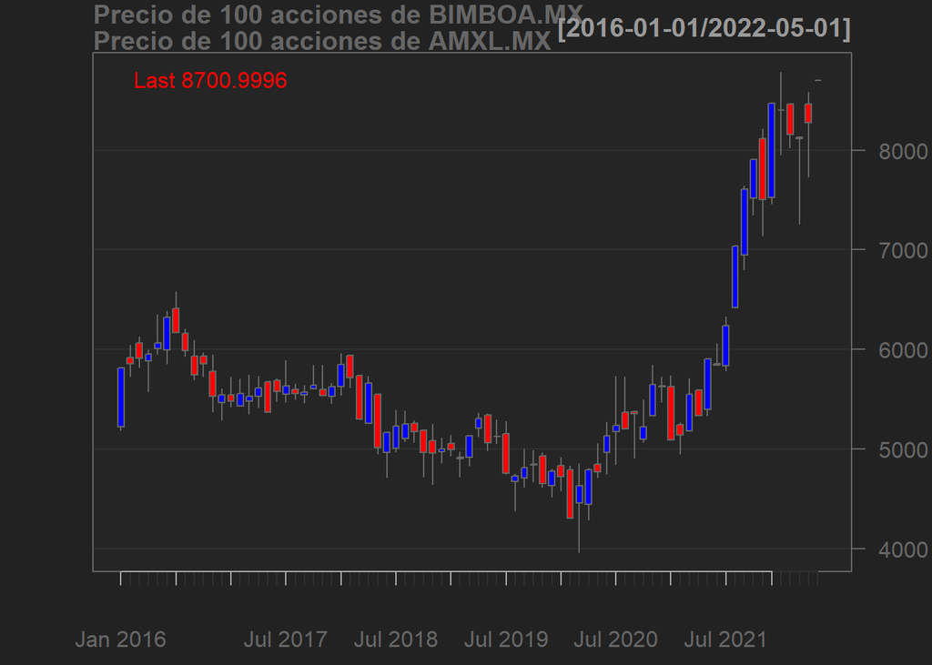

```r
n1 <- 100
n2 <- 100
port <- (n1*precio1)+(n2*precio2)
v_port <- tail(port,1)
names(v_port) <- 'Portafolio'
chartSeries(to.monthly(port), theme="black", up.col="blue", dn.col="red",
            name = paste("Precio de 100 acciones de", clave))
```

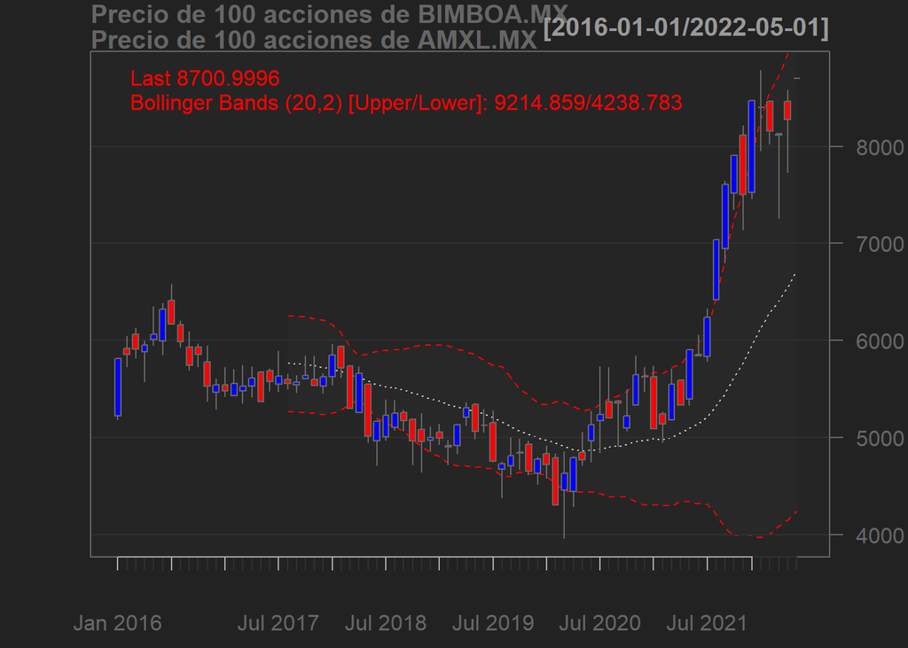

```r
addBBands()
```

La volatilidad en velas mensuales nos indica de un posible retroceso en nuestro portafolio.

El valor del portafolio está dado por: $V_p=(S_{0_{BIMBO}}+S_{0_{AMXL}})*100$ y sus valores fueron los sigs.:

```r
data.frame(port)
```

|  | BIMBOA.MX |
| --- | --- |
| 2016-01-04 | 5225.759 |
| 2016-01-05 | 5290.636 |
| 2016-01-06 | 5289.708 |
| 2016-01-07 | 5275.234 |
| 2016-01-08 | 5274.919 |
| 2016-01-11 | 5366.282 |
| 2016-01-12 | 5371.149 |
| 2016-01-13 | 5402.344 |
| 2016-01-14 | 5425.179 |
| 2016-01-15 | 5371.105 |

[output cut: 1582 more lines]

Su último valor fue de:

```r
v_port
```

```
##            Portafolio
## 2022-05-02       8701
```

### 1.1.2 Matriz de Varianza Covarianza.

La Matriz de covarianza de los últimos es:

```r
getSymbols(clave, from = "2021-11-03", env = datos)
```

```
## [1] "BIMBOA.MX" "AMXL.MX"
```

```r
precio1_6 <- datos[["BIMBOA.MX"]][,6]
precio2_6 <- datos[["AMXL.MX"]][,6]
names(precio1_6) <- "BIMBOA.MX"
names(precio2_6) <- "AMXL.MX"
precios_6 <- merge.xts(precio1_6,precio2_6)
rendimientos_6 <-na.omit(diff(log(precios_6)))
cov <- cov(rendimientos_6)
cov
```

```
##              BIMBOA.MX      AMXL.MX
## BIMBOA.MX 7.004153e-04 8.770462e-05
## AMXL.MX   8.770462e-05 2.162574e-04
```

### 1.1.3 Vector de pesos $w$.

Los pesos del portafolio son de 77.11% para BIMBOA.MX y de 22.89% para AMXL.MX:

```r
port <- (n1*precio1)+(n2*precio2)
v_port <- tail(port,1)
w_1 <- (n1*precio1) / v_port
w_2 <- (n2*precio2) / v_port
w <- cbind(w_1,w_2)
w
```

```
##            BIMBOA.MX   AMXL.MX
## 2022-05-02 0.7710608 0.2289392
```

### 1.1.4 Volatilidad del portafolio **(6meses)**.

La volatilidad del portafolio de 2 activos se puede calcular como
$$\sigma_{port} = \sqrt{{\begin{matrix} [W_1
+ W_2] \end{matrix} \left[\begin{array}{ccc} \sigma_1^2 & cov(1,2)\\
cov(1,2) & \sigma_2^2 \end{array}\right] \left[\begin{array}{ccc}
W_1\\ W_2 \end{array}\right]}}$$

El portafolio tiene la volatilidad diaria y anualizada siguiente al día de la presente entrega para cada valor respectivamente:

```r
s_port <- as.numeric(sqrt(w%*%cov%*%t(w)))
s_port #Diaria
```

```
## [1] 0.02141776
```

```r
s_port*sqrt(252) #Anual
```

```
## [1] 0.3399963
```

### 1.1.5 VaR del portafolio.

El VaR de nuestro portafolio con 2 activos está dado por la sig. expresión:
$$VaR_{port}
= \sqrt{{\begin{matrix} [VaR_1 + VaR_2] \end{matrix}
\left[\begin{array}{ccc} 1 & \rho\\ \rho & 1 \end{array}\right]
\left[\begin{array}{ccc} VaR_1 \\ VaR_2 \end{array}\right]}}$$
Los valores z que utilizaremos de la distribución normal son los siguientes y corresponden a un intervalo de confianza de 99, 95 y 90%:

```r
Z99 <- qnorm(.01)
Z95 <- qnorm(.05)
Z90 <- qnorm(.1)
z <- c(Z99,Z95,Z90)
z
```

```
## [1] -2.326348 -1.644854 -1.281552
```

El VaR Paramétrico a 1,5,10 y 20 días con intervalos de confianza de 90,95 y 99% se expresan en la sig. tabla:

```r
dias <- c(1,5,10,20)
nxm <- matrix(nrow = 4,ncol = 3)

for (j in 1:3){
  for (i in 1:4){
    nxm[i,j] <- sqrt(dias[i])*v_port*s_port*z[j]
  }
}
VaR_Param <- as.data.frame(nxm)
VaR_Param$Dias <- dias
names(VaR_Param) <- c("99%","95%","90%","Días")
VaR_Param
```

| 99% | 95% | 90% | Días |
| --- | --- | --- | --- |
| -433.5286 | -306.5282 | -238.8247 | 1 |
| -969.3995 | -685.4178 | -534.0282 | 5 |
| -1370.9379 | -969.3271 | -755.2299 | 10 |
| -1938.7989 | -1370.8356 | -1068.0564 | 20 |

### 1.1.6 Histograma del VaR.

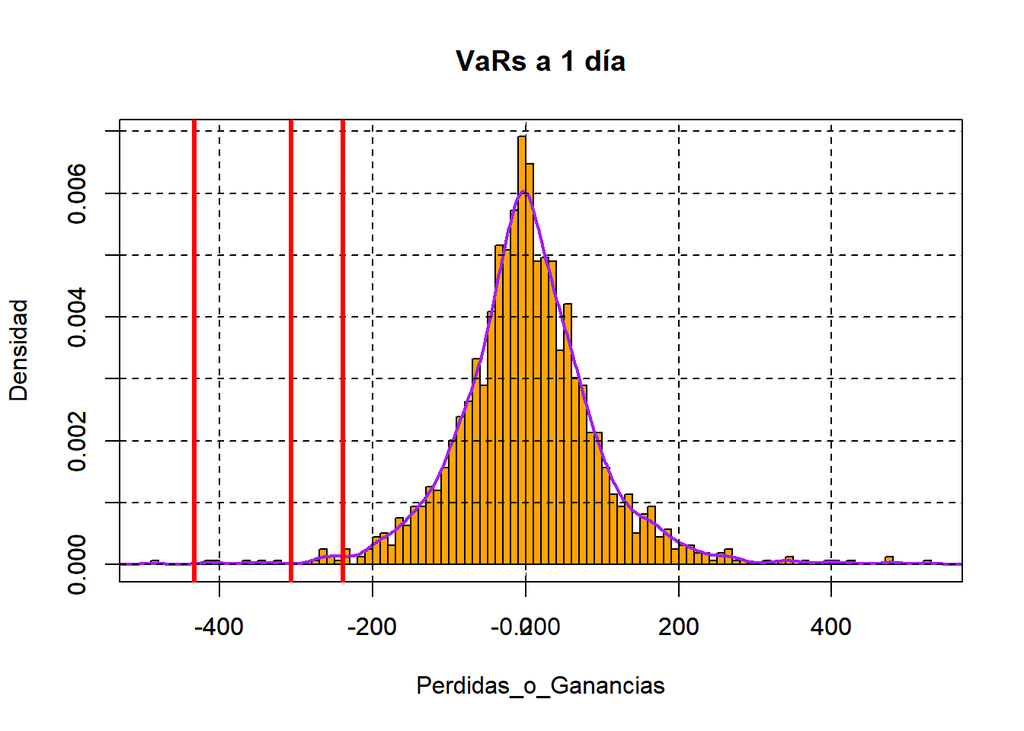

```r
#1día
VaR1d_90 <- VaR_Param[1, 3]
VaR1d_95 <- VaR_Param[1, 2]
VaR1d_99 <- VaR_Param[1, 1]

#Histograma
Perdidas_o_Ganancias <- na.omit(diff(port))
hist(Perdidas_o_Ganancias, n=100, freq=FALSE, main=paste("VaRs a 1 día"), col="orange", ylab="Densidad")
lines(density(Perdidas_o_Ganancias), col='purple', lwd=2)

#Estética
axis(1, tck=1, col.ticks="black", lwd=1, lty = 2)
axis(1, tck=1, at = seq(-.20, .20, by = .025), col.ticks= "black", lty = 2, lwd=.5)
axis(2, tck=1, col.ticks="black", lwd=1, lty = 2)
box()

#Gráficos de VaRs a 1d.
abline(v=VaR1d_90, col='red', lwd=3)
abline(v=VaR1d_95, col='red', lwd=3)
abline(v=VaR1d_99, col='red', lwd=3)
```

### 1.1.7 Backtesting.

```r
btest_90 <- ifelse(Perdidas_o_Ganancias<VaR1d_90,1,0)
btest_95 <- ifelse(Perdidas_o_Ganancias<VaR1d_95,1,0)
btest_99 <- ifelse(Perdidas_o_Ganancias<VaR1d_99,1,0)

(sum(btest_90)/nrow(btest_90))*100
```

```
## [1] 0.8799497
```

```r
(sum(btest_95)/nrow(btest_95))*100
```

```
## [1] 0.3771213
```

```r
(sum(btest_99)/nrow(btest_99))*100
```

```
## [1] 0.06285355
```

Como se puede observar las pérdidas o ganancias diarias observadas para el portafolio creado con BIMBO y America Móvil exceden al VaR en las anteriores proporciones y el riesgo con nuestros valores de significancia se expresa en la sig. tabla:

```r
Resultado <- tibble(ifelse(sum(btest_90)/nrow(btest_90)*100<10, 'Adecuado', 'No Adecuado'),
                           ifelse(sum(btest_95)/nrow(btest_95)*100<5, 'Adecuado', 'No Adecuado'),
                           ifelse(sum(btest_99)/nrow(btest_99)*100<1, 'Adecuado', 'No Adecuado'))
names(Resultado) <- c('90%', '95%', '99%')
Resultado
```

| 90% | 95% | 99% |
| --- | --- | --- |
| Adecuado | Adecuado | Adecuado |

### 1.1.8 Pesos óptimos para minimizar el VaR.

```r
w1_opt <- (2*cov[2,2]-2*cov[1,2]) / (2*cov[1,1] + 2*cov[2,2] + 4*cov[1,2])
w2_opt <- 1- w1_opt

w_optimo <- cbind(w1_opt, w2_opt)
names(w_optimo) <- c("BIMBOA.MX", "AMXL.MX")
w_optimo
```

```
##         w1_opt    w2_opt
## [1,] 0.1177135 0.8822865
## attr(,"names")
## [1] "BIMBOA.MX" "AMXL.MX"
```

```r
(w_optimo-w)*as.numeric(v_port[1,1])
```

```
##               w1_opt   w2_opt
## 2022-05-02 -5684.774 5684.774
```

### 1.1.9 VaR con pesos óptimizados.

El VaR a 1d mínimo con las anteriores modificaciones en las proporciones al portafolio es el siguiente:

```r
n<-nrow(precios)
p_a1 <- as.numeric(precios[n,1])
p_a2 <- as.numeric(precios[n,2])
a1<-100
a2<-100

Z99 <- qnorm(.01)
sigma_opt <- sqrt(w_optimo%*%cov%*%t(w_optimo))
val_p_opt <- w1_opt*p_a1*n1 + w2_opt*p_a2*n2

VaR_opt <- val_p_opt*sigma_opt*Z99
VaR_opt[1,1]
```

```
## [1] -83.01704
```

## 1.2 VaR No Paramétrico.

El VaR no Paramétrico utiliza datos históricos porque su distribución no es normal. La diferencia que existe entre el VaR Paramétrico y el que se presenta a continuación es que el VaR no Paramétrico utiliza simulaciones para lo cual se hace uso de sus históricos. Del mismo modo, se calculará a 1,5,10 y 20 días con intervalos de confianza de 90,95 y 99%.

```r
datos <- new.env()
clave <- c('BIMBOA.MX', 'AMXL.MX')
getSymbols(clave, from = "2016-01-01", env = datos)
```

```
## [1] "BIMBOA.MX" "AMXL.MX"
```

```r
precio1 <- datos[["BIMBOA.MX"]][,6]
precio2 <- datos[["AMXL.MX"]][,6]
names(precio1) <- "BIMBOA.MX"
names(precio2) <- "AMXL.MX"
rend1 <- na.omit(diff(log(precio1)))
rend2 <- na.omit(diff(log(precio2)))
precios <- merge.xts(precio1,precio2)
rendimientos <- merge.xts(rend1,rend2)
n1<-100
n2<-100
n<-nrow(precios)
p_a1 <- as.numeric(precios[n,1])
p_a2 <- as.numeric(precios[n,2])
v_port <- p_a1*n1+p_a2*n2
v_port
```

```
## [1] 8701
```

### 1.2.1 Simulaciones

Las simulaciones se realizan de manera que se utiliza la siguiente fórmula $S_{t+1,n}=S_0(1+R_n)$ que expresa el cambio en el precio con algún rendimiento de los históricos observados.

```r
dia_estimado <- date(precios[n,1])+1
esc_estimado <- seq(1:(n-1))
precio_e_a1<-as.data.frame(p_a1*(1+rendimientos[,1]), row.names = paste("Escenario", esc_estimado))
names(precio_e_a1)<-dia_estimado
precio_e_a2<-as.data.frame(p_a2*(1+rendimientos[,2]), row.names = paste("Escenario", esc_estimado))
names(precio_e_a2)<-dia_estimado
```

Los valores estimados están en el siguiente dataframe.

```r
v_est <- precio_e_a1*n1+precio_e_a2*n2
data.frame(v_est)
```

|  | X2022.05.03 |
| --- | --- |
| Escenario 1 | 8801.886 |
| Escenario 2 | 8691.604 |
| Escenario 3 | 8662.524 |
| Escenario 4 | 8680.801 |
| Escenario 5 | 8852.932 |
| Escenario 6 | 8712.747 |
| Escenario 7 | 8756.691 |
| Escenario 8 | 8748.083 |
| Escenario 9 | 8603.735 |
| Escenario 10 | 8590.003 |

[output cut: 1581 more lines]

El rendimiento promedio $\mu$ para el día de mañana 3 de Mayo es de:

```r
mu_v_est <- mean(v_est[,'2022-05-03'])
((mu_v_est-v_port)/v_port)*100
```

```
## [1] 0.03225201
```

Eso significa que el portafolio se vería así al día de mañana en base a nuestras simulaciones:

### 1.2.2 Perdidas/Ganancias.

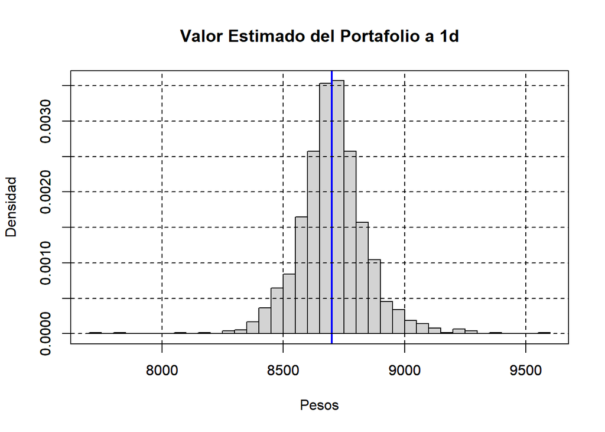

```r
fpg <- v_est-v_port

VaR90 <- quantile(na.omit(fpg[,1]),.1)
VaR95 <- quantile(na.omit(fpg[,1]),.05)
VaR99 <- quantile(na.omit(fpg[,1]),.01)

VaR <- data.frame("VaR99"=VaR99, "VaR95"=VaR95, "VaR90"=VaR90, row.names = dia_estimado)

hist(v_est[,1], n = 50, freq=FALSE, main = "Valor Estimado del Portafolio a 1d", ylab="Densidad", xlab = "Pesos")
abline(v=v_port, col="blue", lwd=2)

#Estética
axis(1, tck=1, col.ticks="black", lwd=1, lty = 2)
axis(1, tck=1, at = seq(-.20, .20, by = .025), col.ticks= "black", lty = 2, lwd=.5)
axis(2, tck=1, col.ticks="black", lwd=1, lty = 2)
box()
```

Simulaciones contenidas en esta tabla:

```r
data.frame(fpg)
```

|  | X2022.05.03 |
| --- | --- |
| Escenario 1 | 100.88635466 |
| Escenario 2 | -9.39582927 |
| Escenario 3 | -38.47543840 |
| Escenario 4 | -20.19860383 |
| Escenario 5 | 151.93228501 |
| Escenario 6 | 11.74759685 |
| Escenario 7 | 55.69165236 |
| Escenario 8 | 47.08324260 |
| Escenario 9 | -97.26490329 |
| Escenario 10 | -110.99653595 |

[output cut: 1581 more lines]

```r
VaR99 <- quantile(na.omit(fpg[,1]),.01)
VaR95 <- quantile(na.omit(fpg[,1]),.05)
VaR90 <- quantile(na.omit(fpg[,1]),.1)
VaR <- data.frame("VaR99"=VaR99, "VaR95"=VaR95, "VaR90"=VaR90, row.names = dia_estimado)
```

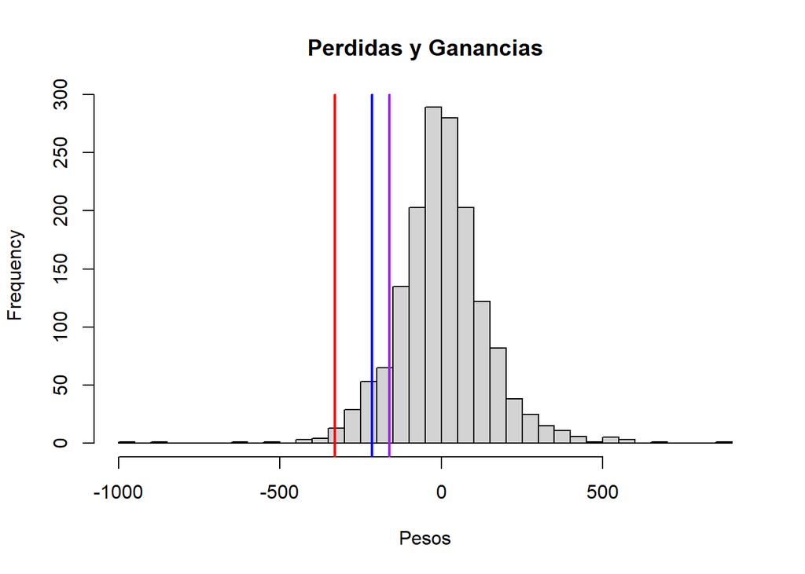

VaR para 1, 5, 10 y 20 días

| 99% | 95% | 90% | # de Días |
| --- | --- | --- | --- |
| -329.4170 | -214.2631 | -160.3648 | 1 |
| -736.5988 | -479.1070 | -358.5866 | 5 |
| -1041.7080 | -677.5596 | -507.1181 | 10 |
| -1473.1976 | -958.2139 | -717.1732 | 20 |

### 1.2.3 Backtesting

Pérdidas/Ganancias.

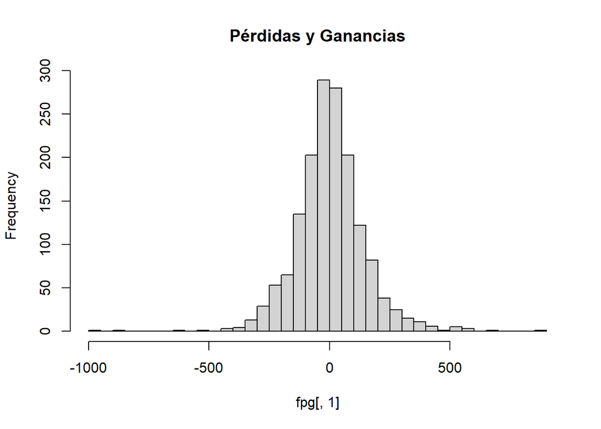

Backtesting

El VaR se compara a continuación con nuestros niveles de significancia de 1, 5 y 10%.

| 99% | 95% | 90% |
| --- | --- | --- |
| 0.31% | 1.19% | 3.46% |
| Adecuado | Adecuado | Adecuado |

### 1.2.4 Composición optima del portafolio que minimice el riesgo.

[output not shown]

### 1.2.5 VaR optimo

[output not shown]

#### 1.2.5.1 Paso 7: Estimar el VAR con los quantiles

En el caso del VAR al 99% para un día, tendríamos lo siguiente:

```r
var99 <- quantile(fpg[,1],0.01)
var99
```

```
##       1%
## -329.417
```